# pisa_visualization_exploratory_analysis

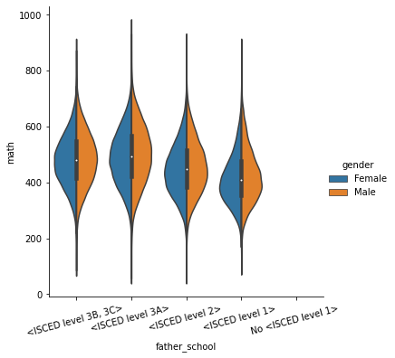

```python
#Visualization of average math results depending on education of their fathers and their gender

sb.catplot(data=data, x="father_school", y="math", hue="gender", kind="violin", split=True)
plt.xticks(rotation=15);
```

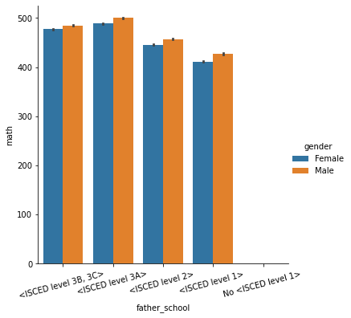

```python
#Visualization of average math results sorted by gender and education of father

sb.catplot(data=data, x='father_school', y="math", hue="gender", kind="bar", height=5)
plt.xticks(rotation=15);
```

Students which fathers achieved ISCED level 3A achieved the best average math results. Male students outperform female students in all categories.

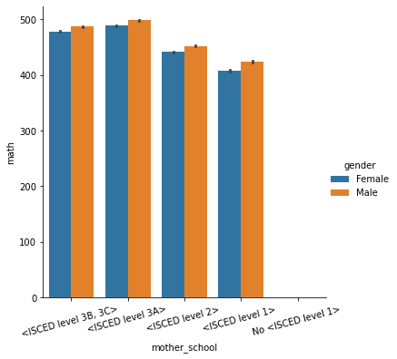

```python
#Visualization of average math results sorted by gender and education of mother

sb.catplot(data=data, x='mother_school', y="math", hue="gender", kind="bar", height=5)
plt.xticks(rotation=15);
```

Students which mothers achieved ISCED level 3A achieved the best average math results. Male students outperform female students in all categories.

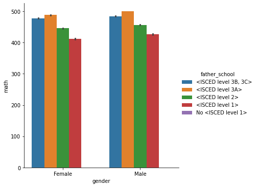

```python
#Visualization of average math results sorted by gender and education of father

sb.catplot(data=data, x="gender", y="math", hue="father_school", kind="bar", height=5);
```

Students which fathers achieved ISCED level 3A achieved the best average math results.

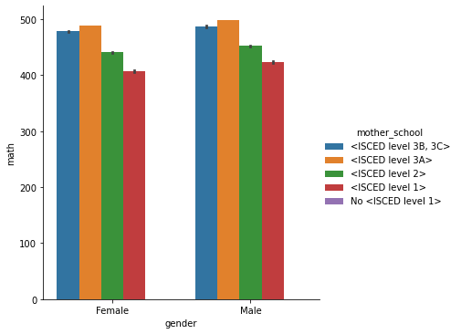

```python
#Visualization of average math results sorted by gender and education of mother

sb.catplot(data=data, x="gender", y="math", hue="mother_school", kind="bar", height=5);
```

Students which mothers achieved ISCED level 3A achieved the best average math results.

### What influence does the job status of mother/father have on the dependent variables?

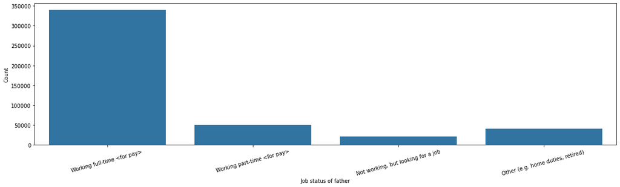

```python
#Visualization of frequency of job status of fathers
plt.figure(figsize=[20, 5])

g = sb.countplot(data=data, x='father_job_status', color=base_color)
g.set_xticklabels(g.get_xticklabels(), rotation=15)
g.set(xlabel='Job status of father', ylabel='Count');
```

Most fathers work full-time.

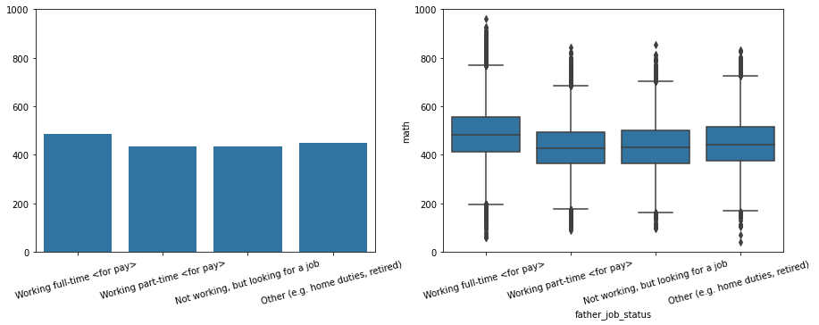

```python
#Visualization of average math results depending on job status of their fathers

father_job_mean = data.groupby(['father_job_status']).mean()

plt.figure(figsize=(15,5))
plt.subplot(1,2,1)
x = father_job_mean.index.values
y = father_job_mean.math.values

g = sb.barplot(x, y, color=base_color)
g.set_ylim(0, 1000)
plt.xticks(rotation=15)

plt.subplot(1,2,2)
g = sb.boxplot(data=data, x='father_job_status', y='math', color=base_color)
g.set_ylim(0, 1000)
plt.xticks(rotation=15);
```

Students which fathers are working full-time achieve best average math results.

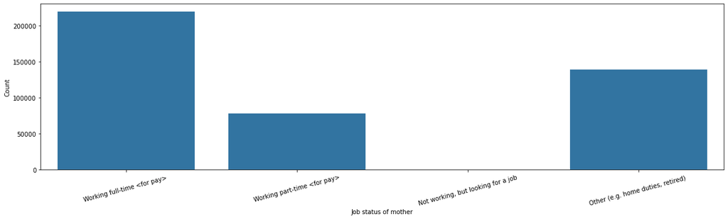

```python
#Visualization of frequency of job status of mothers

plt.figure(figsize=[20, 5])

g = sb.countplot(data=data, x='mother_job_status', color=base_color)
g.set_xticklabels(g.get_xticklabels(), rotation=15)
g.set(xlabel='Job status of mother', ylabel='Count');
```

Most mothers work full-time.

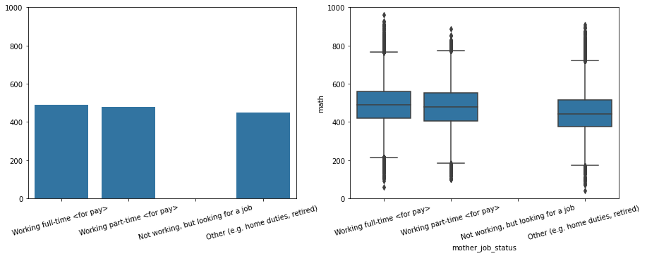

```python
#Visualization of average math results depending on job status of their mothers

mother_job_mean = data.groupby(['mother_job_status']).mean()

plt.figure(figsize=(15,5))

plt.subplot(1,2,1)
x = mother_job_mean.index.values
y = mother_job_mean.math.values

g = sb.barplot(x, y, color=base_color)
g.set_ylim(0, 1000)
plt.xticks(rotation=15)

plt.subplot(1,2,2)
g = sb.boxplot(data=data, x='mother_job_status', y='math', color=base_color)
g.set_ylim(0, 1000)
plt.xticks(rotation=15);
```

Students which mothers are working full-time achieve best average math results but there is almost no difference to the results achieved by students which mothers are working part-time.

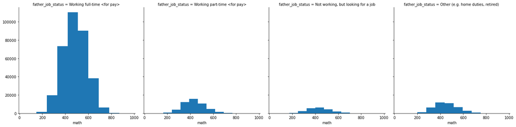

```python
#Visualization of frequency math scores depending on job status of father

g = sb.FacetGrid(data=data, col='father_job_status', col_wrap=4, size=5, margin_titles=True)
g.map(plt.hist, 'math');
```

Different amount of students participated from each category which might influence results.

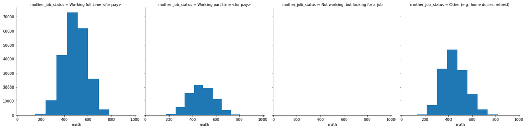

```python
#Visualization of frequency math scores depending on job status of mother

g = sb.FacetGrid(data=data, col='mother_job_status', col_wrap=4, size=5, margin_titles=True)
g.map(plt.hist, 'math');
```

Different amount of students participated from each category which might influence results.

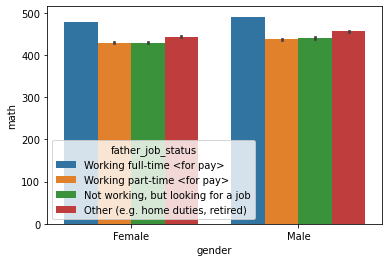

```python
#Visualization of average math results sorted by gender and job status of father

sb.barplot(data=data, x='gender', y='math', hue='father_job_status');
```

Best results are achieved by male and female students of full-time working fathers

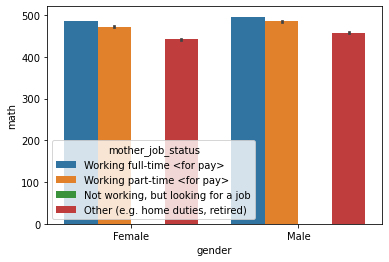

```python
#Visualization of average math results sorted by gender and job status of mother

sb.barplot(data=data, x='gender', y='math', hue='mother_job_status');

#Best results are achieved by male and female students of full-time working mothers
```

### What influence does the country have on the dependent variables?

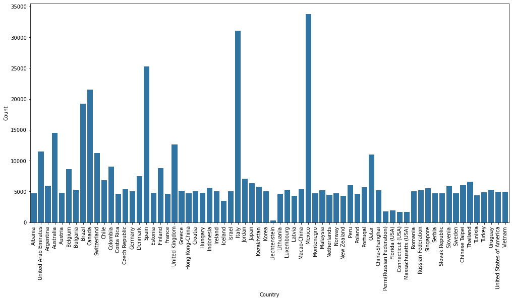

```python
#Visualization of participating students per country

plt.figure(figsize=(17,8))
g = sb.countplot(data=data, x='country', color=base_color)
g.set_xticklabels(g.get_xticklabels(), rotation=90)
g.set(xlabel='Country', ylabel='Count');
```

```python
#Count number of students from country with least participating students
data.country.value_counts().min()
```

```
293
```

```python
#Count number of students from country with most participating students
data.country.value_counts().max()
```

```
33806
```

There are very different numbers of students taking part in the pisa study (ranging from 293 students to 33806 students) which might influence the results.

```python
country_mean = data.groupby(['country']).mean()
country_mean_math_sort = country_mean.sort_values(by=['math'], ascending=False)
country_mean_read_sort = country_mean.sort_values(by=['read'], ascending=False)
country_mean_science_sort = country_mean.sort_values(by=['science'], ascending=False)
```

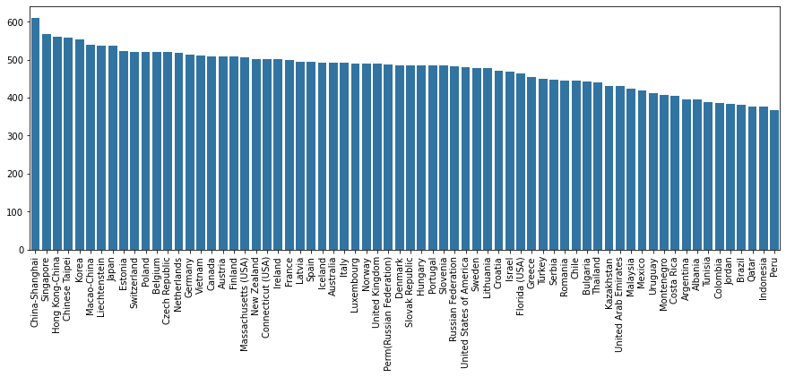

```python
#Visualization of average math results by country

x = country_mean_math_sort.index.values
y = country_mean_math_sort.math.values

plt.figure(figsize=(15,5))
sb.barplot(x, y, color=base_color)
plt.xticks(rotation=90);
```

Shanghai has highest average math results. Peru has lowest average math results.

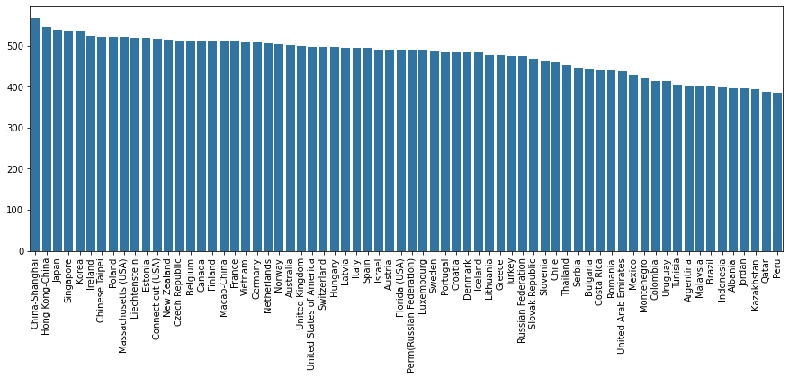

```python
#Visualization of average reading results by country

x = country_mean_read_sort.index.values
y = country_mean_read_sort.read.values

plt.figure(figsize=(15,5))
sb.barplot(x, y, color=base_color)
plt.xticks(rotation=90);
```

Shanghai has highest average reading results. Peru has lowest average reading results.

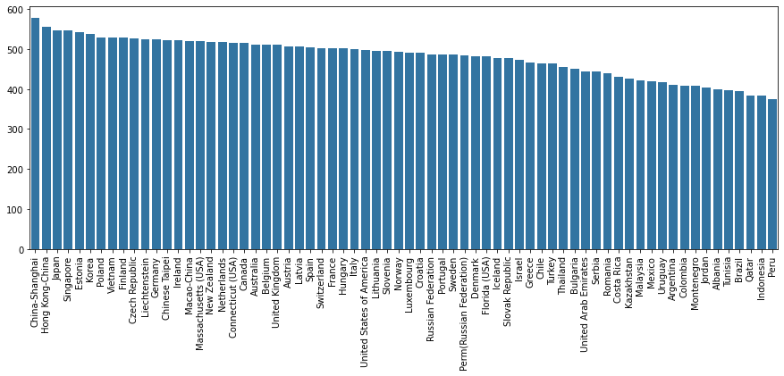

```python
#Visualization of average science results by country

x = country_mean_science_sort.index.values
y = country_mean_science_sort.science.values

plt.figure(figsize=(15,5))
sb.barplot(x, y, color=base_color)
plt.xticks(rotation=90);
```

Shanghai has highest average science results. Peru has lowest average science results.

Students in Shanghai achieve the highest results in math, reading and science. Students in Peru achieve the lowest results in math, reading and science.

In the further analysis, Shanghai and Peru will be compared. Average math results are chosen as a representative for reading and science.

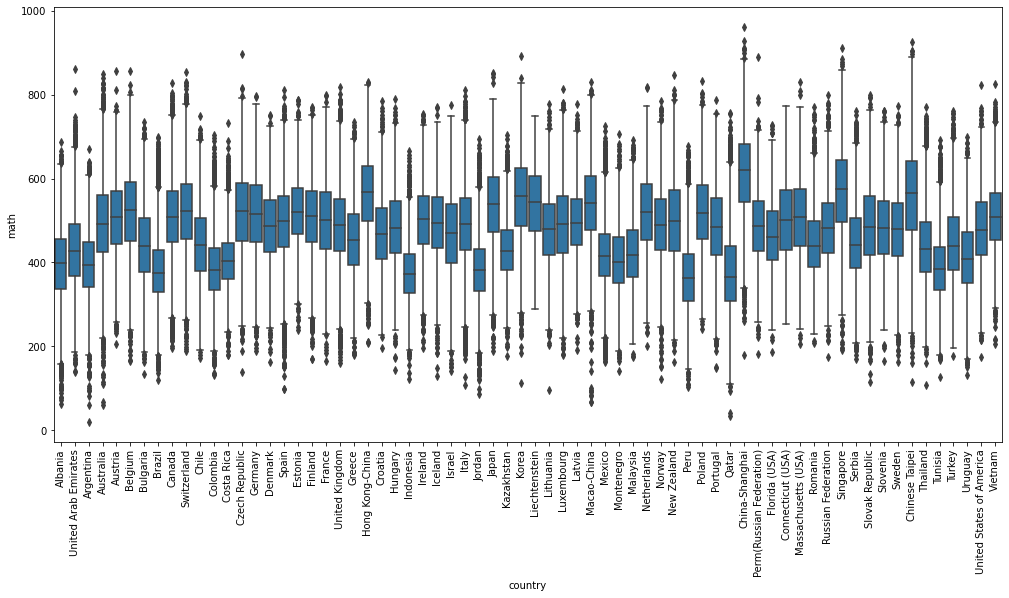

```python
plt.figure(figsize=(17,8))
sb.boxplot(data=data, x='country', y='math', color=base_color)
plt.xticks(rotation=90);
```

Significant variance in average math results in the countries.

### How do Shanghai and Peru differ?

```python
#Comparison between Shanghai and Peru
shanghai = data.query('country == "China-Shanghai"')
peru = data.query('country == "Peru"')
```

#### How do Shanghai and Peru differ in terms of gender?

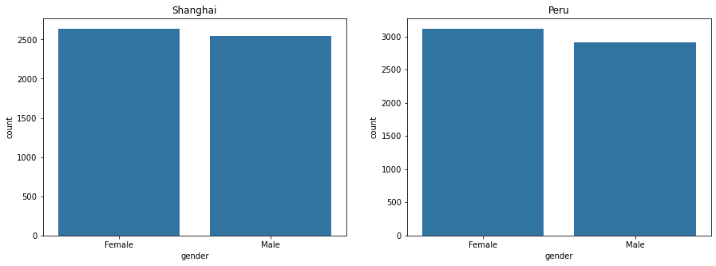

```python
#Visualization of participating students per gender

plt.figure(figsize=(15,5))

plt.subplot(1,2,1)
sb.countplot(data=shanghai, x='gender', color=base_color, order=['Female', 'Male'])
plt.title('Shanghai')

plt.subplot(1,2,2)
sb.countplot(data=peru, x='gender', color=base_color, order=['Female', 'Male'])
plt.title('Peru');
```

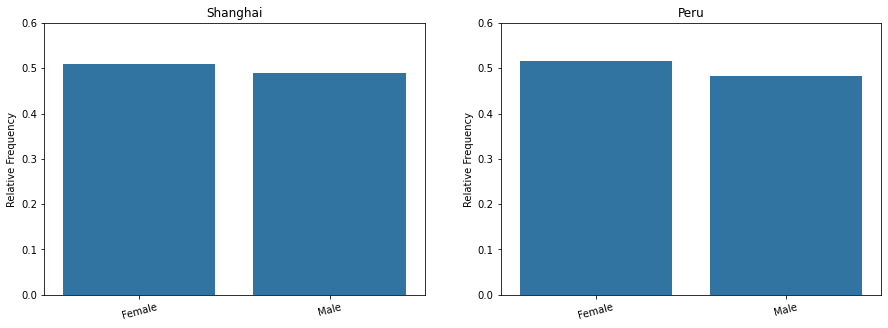

```python
#Visualization of relative frequency of participating students per gender

x1 = shanghai['gender'].value_counts()
shanghai_rel = pd.DataFrame(data=x1)
shanghai_rel['gender'] = shanghai_rel['gender'].astype(float)
y1 = shanghai['gender'].value_counts().sum()
shanghai_rel['gender_rel'] = shanghai_rel['gender'] / y1

x2 = peru['gender'].value_counts()
peru_rel = pd.DataFrame(data=x2)
peru_rel['gender'] = peru_rel['gender'].astype(float)
y2 = peru['gender'].value_counts().sum()
peru_rel['gender_rel'] = peru_rel['gender'] / y2

plt.figure(figsize=(15,5))

plt.subplot(1,2,1)

x3 = shanghai_rel.index.values
y3 = shanghai_rel.gender_rel.values

g = sb.barplot(x3, y3, color=base_color)
g.set_ylim(0, 0.6)
g.set(ylabel='Relative Frequency')
plt.xticks(rotation=15)
plt.title('Shanghai')

plt.subplot(1,2,2)

x4 = peru_rel.index.values
y4 = peru_rel.gender_rel.values

g = sb.barplot(x4, y4, color=base_color)
g.set_ylim(0, 0.6)
g.set(ylabel='Relative Frequency')
plt.xticks(rotation=15)
plt.title('Peru');
```

In both countries slightly more female students participated.

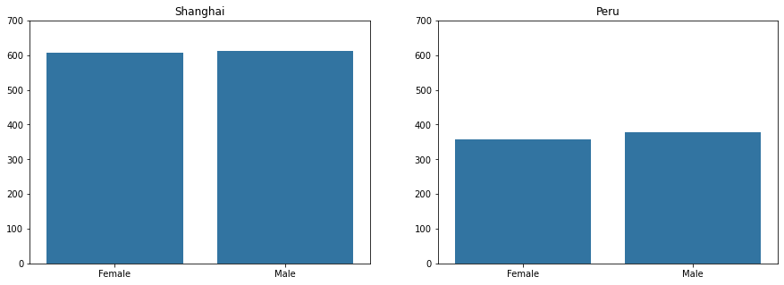

```python
#Visualization of average math results depending on gender

shanghai_mean = shanghai.groupby(['gender']).mean()
peru_mean = peru.groupby(['gender']).mean()

plt.figure(figsize=(15,5))

plt.subplot(1,2,1)
x = shanghai_mean.index.values
y = shanghai_mean.math.values
g = sb.barplot(x, y, color=base_color)
g.set_ylim(0, 700)
plt.title('Shanghai')

plt.subplot(1,2,2)
x = peru_mean.index.values
y = peru_mean.math.values
g = sb.barplot(x, y, color=base_color)
g.set_ylim(0, 700)
plt.title('Peru');
```

Male students perform slightly better in both countries but the difference is a bit smaller in Shanghai.

#### How do Shanghai and Peru differ in terms of computer access?

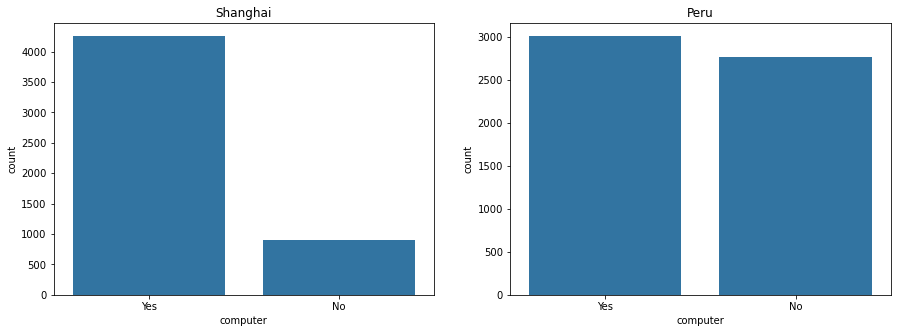

```python
#Visualization of frequency of computer access

plt.figure(figsize=(15,5))

plt.subplot(1,2,1)
sb.countplot(data=shanghai, x='computer', color=base_color, order=['Yes', 'No'])
plt.title('Shanghai')

plt.subplot(1,2,2)
sb.countplot(data=peru, x='computer', color=base_color, order=['Yes', 'No'])
plt.title('Peru');
```

Most students in Shanghai have access to a computer.

In Peru around half of the students have access to a computer, the other half does not have access.

A better comparison will be possible with relative frequencies.

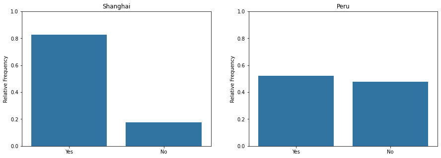

```python
#Visualization of relative frequency of computer access

x1 = shanghai['computer'].value_counts()
shanghai_rel = pd.DataFrame(data=x1)
shanghai_rel['computer'] = shanghai_rel['computer'].astype(float)
y1 = shanghai['computer'].value_counts().sum()
shanghai_rel['computer_rel'] = shanghai_rel['computer'] / y1

x2 = peru['computer'].value_counts()
peru_rel = pd.DataFrame(data=x2)
peru_rel['computer'] = peru_rel['computer'].astype(float)
y2 = peru['computer'].value_counts().sum()
peru_rel['computer_rel'] = peru_rel['computer'] / y2

plt.figure(figsize=(15,5))

plt.subplot(1,2,1)

x3 = shanghai_rel.index.values
y3 = shanghai_rel.computer_rel.values

g = sb.barplot(x3, y3, color=base_color)
g.set_ylim(0, 1)
g.set(ylabel='Relative Frequency')
plt.title('Shanghai')

plt.subplot(1,2,2)

x4 = peru_rel.index.values
y4 = peru_rel.computer_rel.values

g = sb.barplot(x4, y4, color=base_color)
g.set_ylim(0, 1)
g.set(ylabel='Relative Frequency')
plt.title('Peru');
```

About 80% of students in Shanghai have access to a computer. About 50% of students in Peru have access to a computer.

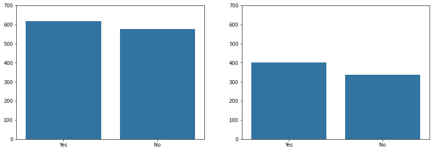

```python
#Visualization of average math results depending on computer access

shanghai_control_mean = shanghai.groupby(['computer']).mean()
peru_control_mean = peru.groupby(['computer']).mean()

plt.figure(figsize=(15,5))

plt.subplot(1,2,1)
x = shanghai_control_mean.index.values
y = shanghai_control_mean.math.values
g = sb.barplot(x, y, color=base_color, order=['Yes', 'No'])
g.set_ylim(0, 700)

plt.subplot(1,2,2)
x = peru_control_mean.index.values
y = peru_control_mean.math.values
g = sb.barplot(x, y, color=base_color, order=['Yes', 'No'])
g.set_ylim(0, 700);
```

Students with access to a computer have better average math results in both countries.

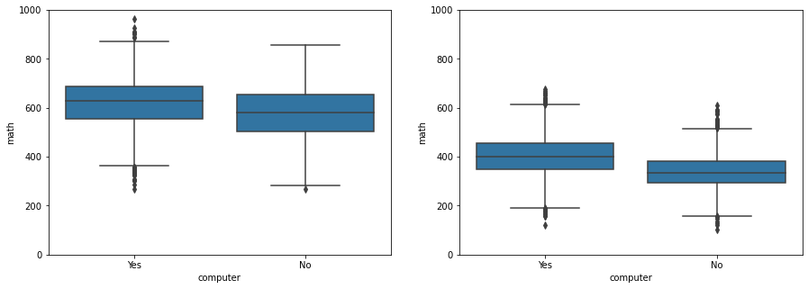

```python
#Visualization of distribution of math results depending on computer access

plt.figure(figsize=(15,5))

plt.subplot(1,2,1)
g = sb.boxplot(data=shanghai, x='computer', y='math', color=base_color, order=['Yes', 'No'])
g.set_ylim(0, 1000)

plt.subplot(1,2,2)
g = sb.boxplot(data=peru, x='computer', y='math', color=base_color, order=['Yes', 'No'])
g.set_ylim(0, 1000);
```

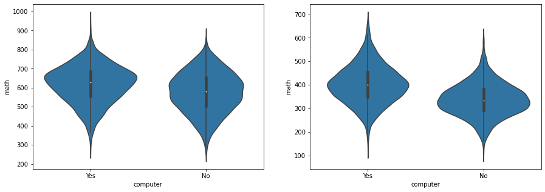

```python
#Visualization of distribution of math results depending on computer access

plt.figure(figsize=(15,5))

plt.subplot(1,2,1)
sb.violinplot(data=shanghai, x='computer', y='math', color=base_color, order=['Yes', 'No'])

plt.subplot(1,2,2)
sb.violinplot(data=peru, x='computer', y='math', color=base_color, order=['Yes', 'No']);
```

#### How do Shanghai and Peru differ in terms of internet access?

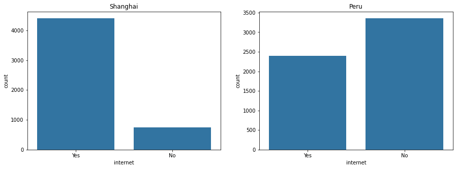

```python
#Visualization of frequency of internet access

plt.figure(figsize=(15,5))

plt.subplot(1,2,1)
sb.countplot(data=shanghai, x='internet', color=base_color, order=['Yes', 'No'])
plt.title('Shanghai')

plt.subplot(1,2,2)
sb.countplot(data=peru, x='internet', color=base_color, order=['Yes', 'No'])
plt.title('Peru');
```

There are differences in the pattern of answers.

Most students have internet access in Shanghai.

Most students don't have internet access in Peru.

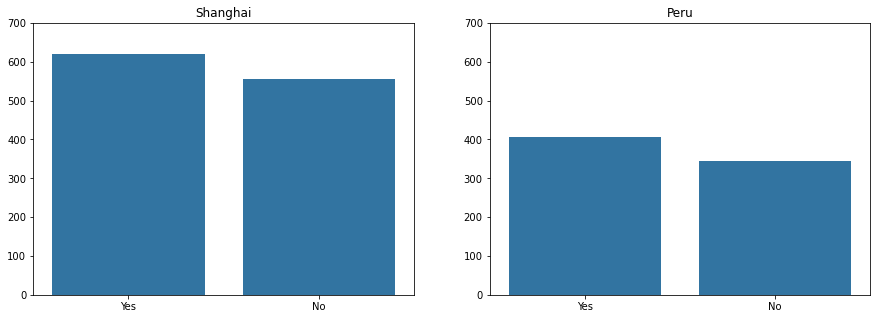

```python
#Visualization of average math results depending on internet access

shanghai_control_mean = shanghai.groupby(['internet']).mean()
peru_control_mean = peru.groupby(['internet']).mean()

plt.figure(figsize=(15,5))

plt.subplot(1,2,1)
x = shanghai_control_mean.index.values
y = shanghai_control_mean.math.values
g = sb.barplot(x, y, color=base_color, order=['Yes', 'No'])
g.set_ylim(0, 700)
plt.title('Shanghai')

plt.subplot(1,2,2)
x = peru_control_mean.index.values
y = peru_control_mean.math.values
g = sb.barplot(x, y, color=base_color, order=['Yes', 'No'])
g.set_ylim(0, 700)
plt.title('Peru');
```

The same trend visible is visible in both countries. Students with internet access have better math results.

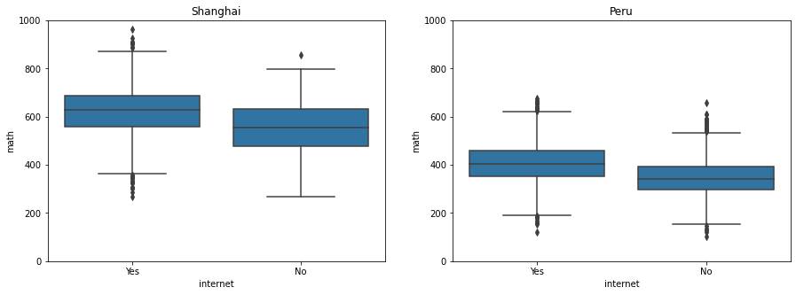

```python
#Visualization of distribution of math results depending on internet access

plt.figure(figsize=(15,5))

plt.subplot(1,2,1)
g = sb.boxplot(data=shanghai, x='internet', y='math', color=base_color, order=['Yes', 'No'])
g.set_ylim(0, 1000)
plt.title('Shanghai')

plt.subplot(1,2,2)
g = sb.boxplot(data=peru, x='internet', y='math', color=base_color, order=['Yes', 'No'])
g.set_ylim(0, 1000)
plt.title('Peru');
```

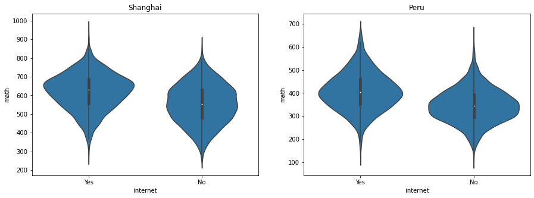

```python
#Visualization of distribution of math results depending on internet access

plt.figure(figsize=(15,5))

plt.subplot(1,2,1)
sb.violinplot(data=shanghai, x='internet', y='math', color=base_color, order=['Yes', 'No'])
plt.title('Shanghai')

plt.subplot(1,2,2)
sb.violinplot(data=peru, x='internet', y='math', color=base_color, order=['Yes', 'No'])
plt.title('Peru');
```

#### How do Shanghai and Peru differ in terms of self concept?

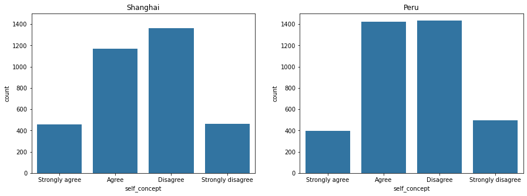

```python
#Visualization of frequency of answers in regard to self concept ('I am not good at math')

plt.figure(figsize=(15,5))

plt.subplot(1,2,1)
g = sb.countplot(data=shanghai, x='self_concept', color=base_color)
plt.title('Shanghai')
g.set_ylim(0, 1500)

plt.subplot(1,2,2)
g = sb.countplot(data=peru, x='self_concept', color=base_color)
plt.title('Peru')
g.set_ylim(0, 1500);
```

There are differences in the pattern of answers. A better comparison will be possible with relative frequencies.

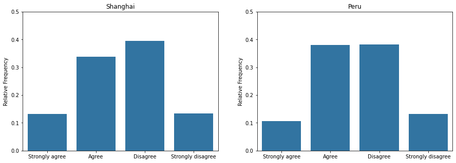

```python
#Visualization of relative frequency of self concept

x1 = shanghai['self_concept'].value_counts()
shanghai_rel = pd.DataFrame(data=x1)
shanghai_rel['self_concept'] = shanghai_rel['self_concept'].astype(float)
y1 = shanghai['self_concept'].value_counts().sum()
shanghai_rel['self_concept_rel'] = shanghai_rel['self_concept'] / y1

x2 = peru['self_concept'].value_counts()
peru_rel = pd.DataFrame(data=x2)
peru_rel['self_concept'] = peru_rel['self_concept'].astype(float)
y2 = peru['self_concept'].value_counts().sum()
peru_rel['self_concept_rel'] = peru_rel['self_concept'] / y2

plt.figure(figsize=(15,5))

plt.subplot(1,2,1)

x3 = shanghai_rel.index.values
y3 = shanghai_rel.self_concept_rel.values

g = sb.barplot(x3, y3, color=base_color)
g.set_ylim(0, 0.5)
g.set(ylabel='Relative Frequency')
plt.title('Shanghai')

plt.subplot(1,2,2)

x4 = peru_rel.index.values
y4 = peru_rel.self_concept_rel.values

g = sb.barplot(x4, y4, color=base_color)
g.set_ylim(0, 0.5)
g.set(ylabel='Relative Frequency')
plt.title('Peru');
```

Most common answer in Shanghai is 'Disagree', followed by 'Agree'

Most common answers in Peru are 'Agree' and 'Disagree' which are almost on the same level.

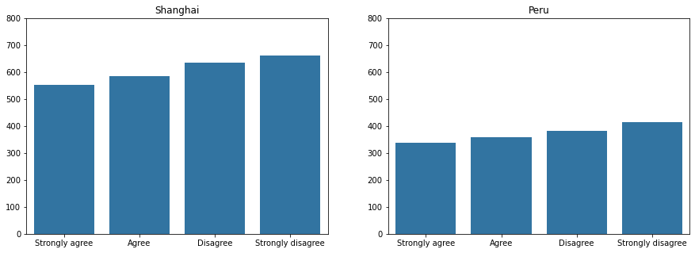

```python
#Visualization of average math results depending on self concept

shanghai_control_mean = shanghai.groupby(['self_concept']).mean()
peru_control_mean = peru.groupby(['self_concept']).mean()

plt.figure(figsize=(15,5))

plt.subplot(1,2,1)
x = shanghai_control_mean.index.values
y = shanghai_control_mean.math.values
g = sb.barplot(x, y, color=base_color)
g.set_ylim(0, 800)
plt.title('Shanghai')

plt.subplot(1,2,2)
x = peru_control_mean.index.values
y = peru_control_mean.math.values
g = sb.barplot(x, y, color=base_color)
g.set_ylim(0, 800)
plt.title('Peru');
```

The same trend is visible for both countries. The average math results are higher if students think that they are 'good at math'.

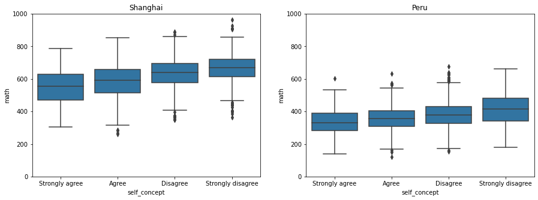

```python
#Visualization of distribution of math results depending on self concept

plt.figure(figsize=(15,5))

plt.subplot(1,2,1)
g = sb.boxplot(data=shanghai, x='self_concept', y='math', color=base_color)
g.set_ylim(0, 1000)
plt.title('Shanghai')

plt.subplot(1,2,2)
g = sb.boxplot(data=peru, x='self_concept', y='math', color=base_color)
g.set_ylim(0, 1000)
plt.title('Peru');
```

In Shanghai the variance of results constantly decreases from 'Strongly agree' to 'Strongly disagree' - being highest for 'Strongly agree'.

In Peru the variance is almost similar for all categories except for 'Strongly disagree' where the variance is higher.

Generally, the variance in Peru is smaller than in Shanghai.

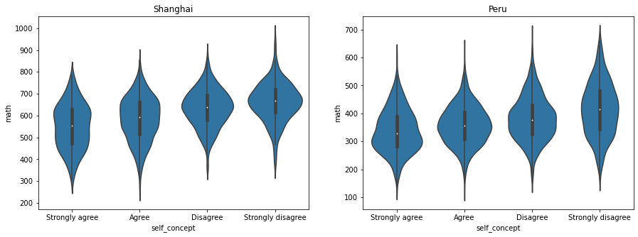

```python
#Visualization of distribution of math results depending on self concept

plt.figure(figsize=(15,5))

plt.subplot(1,2,1)
sb.violinplot(data=shanghai, x='self_concept', y='math', color=base_color)
plt.title('Shanghai')

plt.subplot(1,2,2)
sb.violinplot(data=peru, x='self_concept', y='math', color=base_color)
plt.title('Peru');
```

#### How do Shanghai and Peru differ in terms of perceived control?

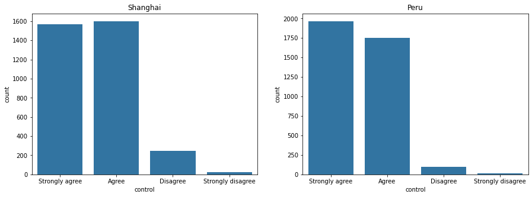

```python
#Visualization of frequency of answers in regard to perceived control

plt.figure(figsize=(15,5))

plt.subplot(1,2,1)
sb.countplot(data=shanghai, x='control', color=base_color)
plt.title('Shanghai')

plt.subplot(1,2,2)
sb.countplot(data=peru, x='control', color=base_color)
plt.title('Peru');
```

There are differences in the pattern of answers. A better comparison will be possible with relative frequencies.

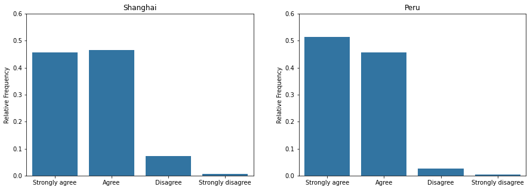

```python
#Visualization of relative frequency of perceived control

x1 = shanghai['control'].value_counts()
shanghai_rel = pd.DataFrame(data=x1)
shanghai_rel['control'] = shanghai_rel['control'].astype(float)
y1 = shanghai['control'].value_counts().sum()
shanghai_rel['control_rel'] = shanghai_rel['control'] / y1

x2 = peru['control'].value_counts()
peru_rel = pd.DataFrame(data=x2)
peru_rel['control'] = peru_rel['control'].astype(float)
y2 = peru['control'].value_counts().sum()
peru_rel['control_rel'] = peru_rel['control'] / y2

plt.figure(figsize=(15,5))

plt.subplot(1,2,1)

x3 = shanghai_rel.index.values
y3 = shanghai_rel.control_rel.values

g = sb.barplot(x3, y3, color=base_color)
g.set_ylim(0, 0.6)
g.set(ylabel='Relative Frequency')
plt.title('Shanghai')

plt.subplot(1,2,2)

x4 = peru_rel.index.values
y4 = peru_rel.control_rel.values

g = sb.barplot(x4, y4, color=base_color)
g.set_ylim(0, 0.6)
g.set(ylabel='Relative Frequency')
plt.title('Peru');
```

Overall pattern of answers is similar. Most students in both countries 'Agree' or 'Strongly agree' with the statement.

```python
shanghai_control_mean = shanghai.groupby(['control']).mean()
peru_control_mean = peru.groupby(['control']).mean()
```

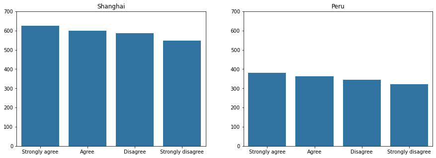

```python
#Visualization of average math results depending on perceived control

plt.figure(figsize=(15,5))

plt.subplot(1,2,1)
x = shanghai_control_mean.index.values
y = shanghai_control_mean.math.values
g = sb.barplot(x, y, color=base_color)
g.set_ylim(0,700)
plt.title('Shanghai')

plt.subplot(1,2,2)
x = peru_control_mean.index.values
y = peru_control_mean.math.values
g = sb.barplot(x, y, color=base_color)
g.set_ylim(0,700)
plt.title('Peru');
```

Same trend is visible for both countries. The more students agree with the statement the higher their average math results.

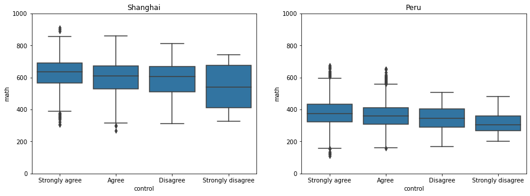

```python
#Visualization of distribution of math results depending on perceived control

plt.figure(figsize=(15,5))

plt.subplot(1,2,1)
g = sb.boxplot(data=shanghai, x='control', y='math', color=base_color)
g.set_ylim(0,1000)
plt.title('Shanghai')

plt.subplot(1,2,2)
g = sb.boxplot(data=peru, x='control', y='math', color=base_color);
g.set_ylim(0,1000)
plt.title('Peru');
```

Same trend is visible for both countries. There is a larger variance in results for students that 'Strongly disagree' with the statement in Shanghai which can't be observed in Peru.

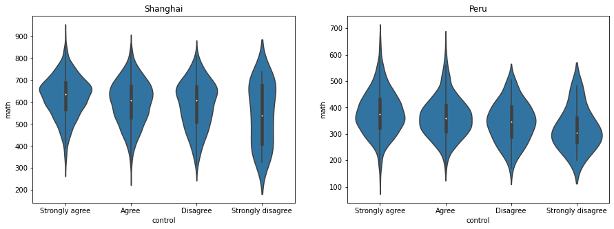

```python
#Visualization of distribution of math results depending on perceived control

plt.figure(figsize=(15,5))

plt.subplot(1,2,1)
sb.violinplot(data=shanghai, x='control', y='math', color=base_color)
plt.title('Shanghai')

plt.subplot(1,2,2)
sb.violinplot(data=peru, x='control', y='math', color=base_color)
plt.title('Peru');
```

#### How do Shanghai and Peru differ in terms of education of parents?

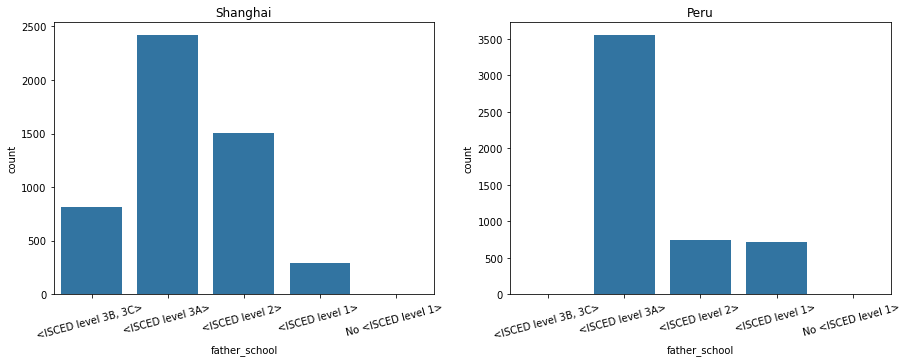

```python
#Visualization of frequency of highest achieved education of fathers

plt.figure(figsize=(15,5))

plt.subplot(1,2,1)
sb.countplot(data=shanghai, x='father_school', color=base_color)
plt.xticks(rotation=15)
plt.title('Shanghai')

plt.subplot(1,2,2)
sb.countplot(data=peru, x='father_school', color=base_color)
plt.xticks(rotation=15)
plt.title('Peru');
```

In both countries are no fathers with no ISCED level 1 education. Most fathers achieve a ISCED level 3A education in both countries. In Peru no fathers achieve ISCED level 3B education.

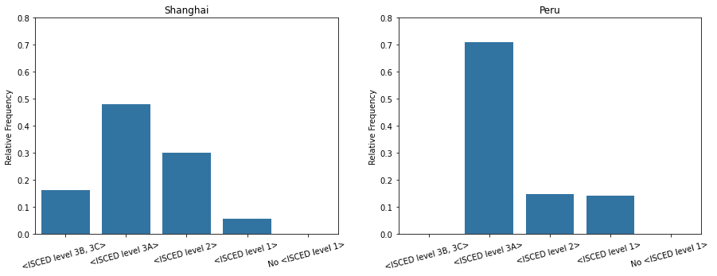

```python
#Visualization of relative frequency of highest achieved education of fathers

x1 = shanghai['father_school'].value_counts()
shanghai_rel = pd.DataFrame(data=x1)
shanghai_rel['father_school'] = shanghai_rel['father_school'].astype(float)
y1 = shanghai['father_school'].value_counts().sum()
shanghai_rel['father_school_rel'] = shanghai_rel['father_school'] / y1

x2 = peru['father_school'].value_counts()
peru_rel = pd.DataFrame(data=x2)
peru_rel['father_school'] = peru_rel['father_school'].astype(float)
y2 = peru['father_school'].value_counts().sum()
peru_rel['father_school_rel'] = peru_rel['father_school'] / y2

plt.figure(figsize=(15,5))

plt.subplot(1,2,1)

x3 = shanghai_rel.index.values
y3 = shanghai_rel.father_school_rel.values

g = sb.barplot(x3, y3, color=base_color)
g.set_ylim(0, 0.8)
g.set(ylabel='Relative Frequency')
plt.xticks(rotation=15)
plt.title('Shanghai')

plt.subplot(1,2,2)

x4 = peru_rel.index.values
y4 = peru_rel.father_school_rel.values

g = sb.barplot(x4, y4, color=base_color)
g.set_ylim(0, 0.8)
g.set(ylabel='Relative Frequency')
plt.xticks(rotation=15)
plt.title('Peru');
```

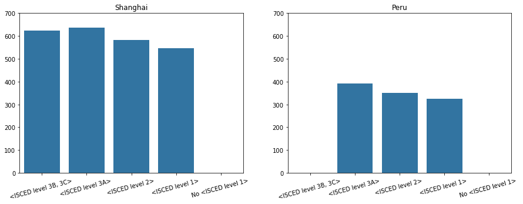

```python
#Visualization of relative frequency of highest achieved education of fathers

shanghai_control_mean = shanghai.groupby(['father_school']).mean()
peru_control_mean = peru.groupby(['father_school']).mean()

plt.figure(figsize=(15,5))

plt.subplot(1,2,1)
x = shanghai_control_mean.index.values
y = shanghai_control_mean.math.values
g = sb.barplot(x, y, color=base_color)
g.set_ylim(0, 700)
plt.xticks(rotation=15)
plt.title('Shanghai')

plt.subplot(1,2,2)
x = peru_control_mean.index.values
y = peru_control_mean.math.values
g = sb.barplot(x, y, color=base_color)
g.set_ylim(0, 700)
plt.xticks(rotation=15)
plt.title('Peru');
```

Same trend is visible in both countries. Highest average math results are achieved by students which fathers achieved a ISCED level 3A education and lower in both countries for each lower level of education of fatheres. No fathers achieved ISCED level 3B or higher education in Peru. Therefore, no comparison is possible in this category.

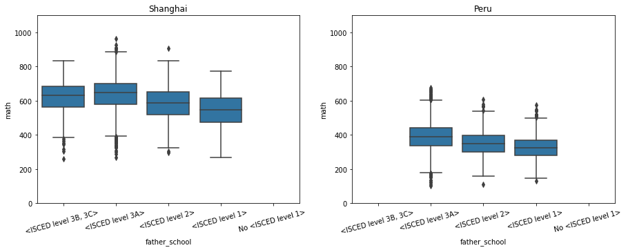

```python
#Visualization of distribution of math results depending on education of fathers

plt.figure(figsize=(15,5))

plt.subplot(1,2,1)
g = sb.boxplot(data=shanghai, x='father_school', y='math', color=base_color)
plt.xticks(rotation=15)
g.set_ylim(0, 1100)
plt.title('Shanghai')

plt.subplot(1,2,2)
g = sb.boxplot(data=peru, x='father_school', y='math', color=base_color)
plt.xticks(rotation=15)
g.set_ylim(0, 1100)
plt.title('Peru');
```

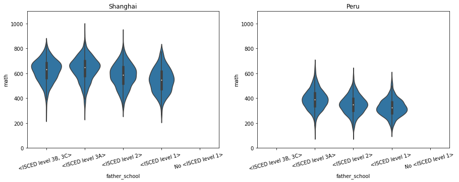

```python
#Visualization of distribution of math results depending on education of fathers

plt.figure(figsize=(15,5))

plt.subplot(1,2,1)
g = sb.violinplot(data=shanghai, x='father_school', y='math', color=base_color)
plt.xticks(rotation=15)
g.set_ylim(0, 1100)
plt.title('Shanghai')

plt.subplot(1,2,2)
g = sb.violinplot(data=peru, x='father_school', y='math', color=base_color)
plt.xticks(rotation=15)
g.set_ylim(0, 1100)
plt.title('Peru');
```

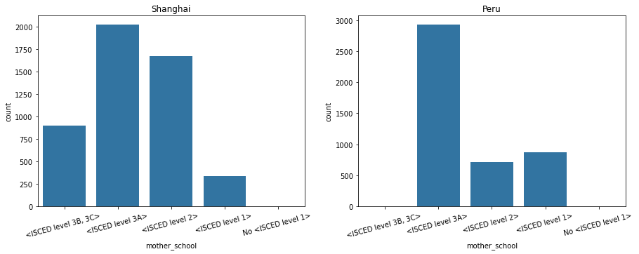

```python
#Visualization of frequency of highest achieved education of mothers

plt.figure(figsize=(15,5))

plt.subplot(1,2,1)
sb.countplot(data=shanghai, x='mother_school', color=base_color)
plt.xticks(rotation=15)
plt.title('Shanghai')

plt.subplot(1,2,2)
sb.countplot(data=peru, x='mother_school', color=base_color)
plt.xticks(rotation=15)
plt.title('Peru');
```

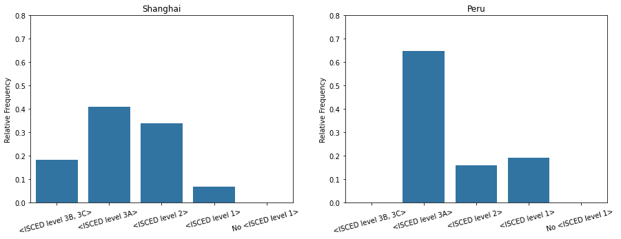

```python
#Visualization of relative frequency of highest achieved education of mothers

x1 = shanghai['mother_school'].value_counts()
shanghai_rel = pd.DataFrame(data=x1)
shanghai_rel['mother_school'] = shanghai_rel['mother_school'].astype(float)
y1 = shanghai['mother_school'].value_counts().sum()
shanghai_rel['mother_school_rel'] = shanghai_rel['mother_school'] / y1

x2 = peru['mother_school'].value_counts()
peru_rel = pd.DataFrame(data=x2)
peru_rel['mother_school'] = peru_rel['mother_school'].astype(float)
y2 = peru['mother_school'].value_counts().sum()
peru_rel['mother_school_rel'] = peru_rel['mother_school'] / y2

plt.figure(figsize=(15,5))

plt.subplot(1,2,1)

x3 = shanghai_rel.index.values
y3 = shanghai_rel.mother_school_rel.values

g = sb.barplot(x3, y3, color=base_color)
g.set_ylim(0, 0.8)
g.set(ylabel='Relative Frequency')
plt.xticks(rotation=15)
plt.title('Shanghai')

plt.subplot(1,2,2)

x4 = peru_rel.index.values
y4 = peru_rel.mother_school_rel.values

g = sb.barplot(x4, y4, color=base_color)
g.set_ylim(0, 0.8)
g.set(ylabel='Relative Frequency')
plt.xticks(rotation=15)
plt.title('Peru');
```

The most common education level in both countries is ISCED level 3A. However, it is more common in Peru with more than 60% compared to Shanghai with around 40%.

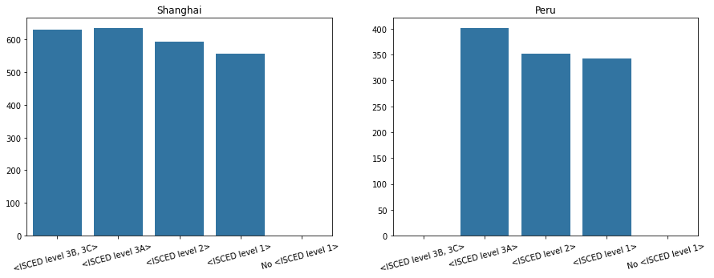

```python
#visualization of average math results depending on education of mothers

shanghai_control_mean = shanghai.groupby(['mother_school']).mean()
peru_control_mean = peru.groupby(['mother_school']).mean()

plt.figure(figsize=(15,5))

plt.subplot(1,2,1)
x = shanghai_control_mean.index.values
y = shanghai_control_mean.math.values
sb.barplot(x, y, color=base_color)
plt.xticks(rotation=15)
plt.title('Shanghai')

plt.subplot(1,2,2)
x = peru_control_mean.index.values
y = peru_control_mean.math.values
sb.barplot(x, y, color=base_color)
plt.xticks(rotation=15)
plt.title('Peru');
```

Same trend is visible in both countries. Highest average math results are achieved by students which mothers achieved a ISCED level 3A education and lower in both countries for each lower level of education of motheres. No mothers achieved ISCED level 3B or higher education in Peru. Therefore, no comparison is possible in this category.

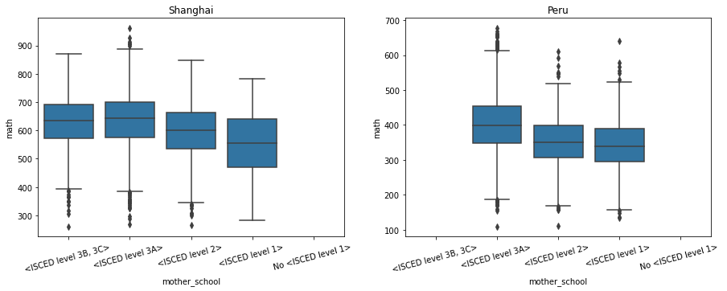

```python
#Visualization of distribution of math results depending on education of mothers

plt.figure(figsize=(15,5))

plt.subplot(1,2,1)
sb.boxplot(data=shanghai, x='mother_school', y='math', color=base_color)
plt.xticks(rotation=15)
plt.title('Shanghai')

plt.subplot(1,2,2)
sb.boxplot(data=peru, x='mother_school', y='math', color=base_color)
plt.xticks(rotation=15)
plt.title('Peru');
```

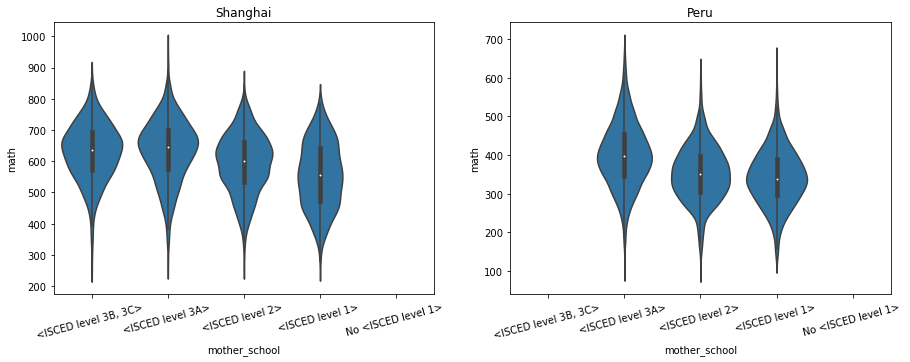

```python
#Visualization of distribution of math results depending on education of mothers

plt.figure(figsize=(15,5))

plt.subplot(1,2,1)
sb.violinplot(data=shanghai, x='mother_school', y='math', color=base_color)
plt.xticks(rotation=15)
plt.title('Shanghai')

plt.subplot(1,2,2)
sb.violinplot(data=peru, x='mother_school', y='math', color=base_color)
plt.xticks(rotation=15)
plt.title('Peru');
```

#### How do Shanghai and Peru differ in terms of job status of parents?

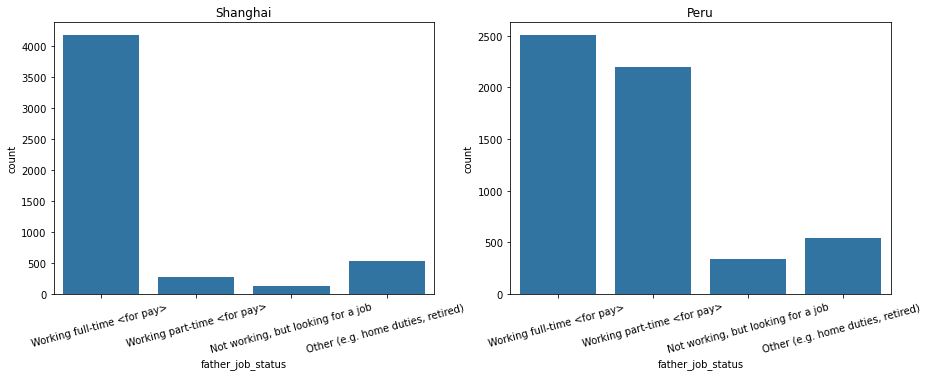

```python
#Visualization of relative frequency of job status of fathers

plt.figure(figsize=(15,5))

plt.subplot(1,2,1)
sb.countplot(data=shanghai, x='father_job_status', color=base_color)
plt.xticks(rotation=15)
plt.title('Shanghai')

plt.subplot(1,2,2)
sb.countplot(data=peru, x='father_job_status', color=base_color)
plt.xticks(rotation=15)
plt.title('Peru');
```

A better comparison will be possible with relative frequencies.

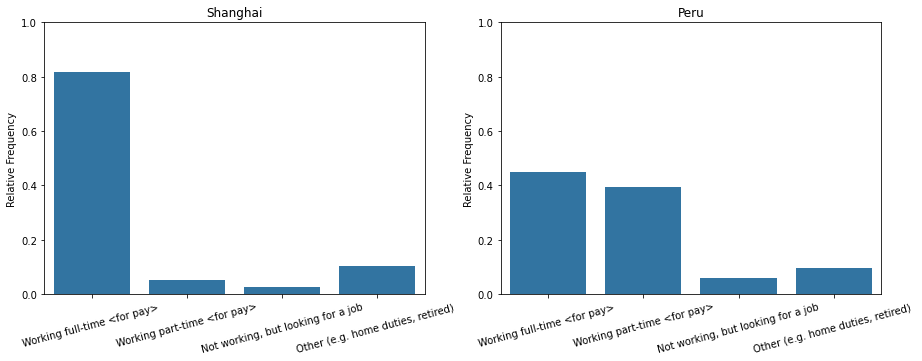

```python
#Visualization of relative frequency of job status of fathers

x1 = shanghai['father_job_status'].value_counts()
shanghai_rel = pd.DataFrame(data=x1)
shanghai_rel['father_job_status'] = shanghai_rel['father_job_status'].astype(float)
y1 = shanghai['father_job_status'].value_counts().sum()
shanghai_rel['father_job_status_rel'] = shanghai_rel['father_job_status'] / y1

x2 = peru['father_job_status'].value_counts()
peru_rel = pd.DataFrame(data=x2)
peru_rel['father_job_status'] = peru_rel['father_job_status'].astype(float)
y2 = peru['father_job_status'].value_counts().sum()
peru_rel['father_job_status_rel'] = peru_rel['father_job_status'] / y2

plt.figure(figsize=(15,5))

plt.subplot(1,2,1)

x3 = shanghai_rel.index.values
y3 = shanghai_rel.father_job_status_rel.values

g = sb.barplot(x3, y3, color=base_color)
g.set_ylim(0, 1)
g.set(ylabel='Relative Frequency')
plt.xticks(rotation=15)
plt.title('Shanghai')

plt.subplot(1,2,2)

x4 = peru_rel.index.values
y4 = peru_rel.father_job_status_rel.values

g = sb.barplot(x4, y4, color=base_color)
g.set_ylim(0, 1)
g.set(ylabel='Relative Frequency')
plt.xticks(rotation=15)
plt.title('Peru');
```

There is a difference in both countries.

Most fathers work full-time in Shanghai.

Most fathers work full-time but a lot also work part-time in Peru.

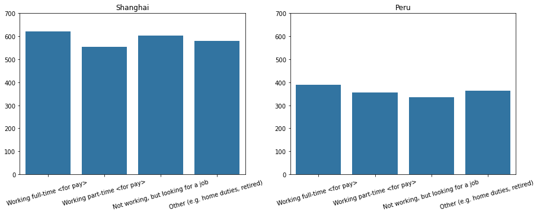

```python
#Visualization of average math results depending on fathers job status

shanghai_control_mean = shanghai.groupby(['father_job_status']).mean()
peru_control_mean = peru.groupby(['father_job_status']).mean()

plt.figure(figsize=(15,5))

plt.subplot(1,2,1)
x = shanghai_control_mean.index.values
y = shanghai_control_mean.math.values
g = sb.barplot(x, y, color=base_color)
g.set_ylim(0, 700)
plt.xticks(rotation=15)
plt.title('Shanghai')

plt.subplot(1,2,2)
x = peru_control_mean.index.values
y = peru_control_mean.math.values
g = sb.barplot(x, y, color=base_color)
g.set_ylim(0, 700)
plt.xticks(rotation=15)
plt.title('Peru');
```

In both countries the students of full-time working fathers perform best. However, the order of average results is not the same in both countries.

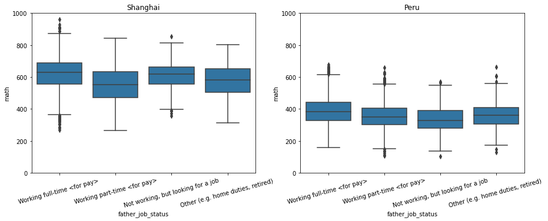

```python
#Visualization of distribution of math results depending on fathers job status

plt.figure(figsize=(15,5))

plt.subplot(1,2,1)
g = sb.boxplot(data=shanghai, x='father_job_status', y='math', color=base_color)
plt.xticks(rotation=15)
g.set_ylim(0,1000)
plt.title('Shanghai')

plt.subplot(1,2,2)
g = sb.boxplot(data=peru, x='father_job_status', y='math', color=base_color)
plt.xticks(rotation=15)
g.set_ylim(0,1000)
plt.title('Peru');
```

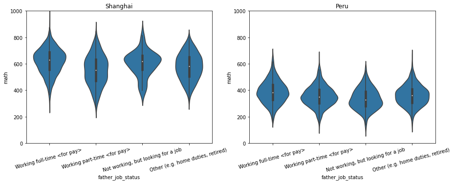

```python
#Visualization of distribution of math results depending on fathers job status

plt.figure(figsize=(15,5))

plt.subplot(1,2,1)
g = sb.violinplot(data=shanghai, x='father_job_status', y='math', color=base_color)
plt.xticks(rotation=15)
g.set_ylim(0,1000)
plt.title('Shanghai')

plt.subplot(1,2,2)
g = sb.violinplot(data=peru, x='father_job_status', y='math', color=base_color)
plt.xticks(rotation=15)
g.set_ylim(0,1000)
plt.title('Peru');
```

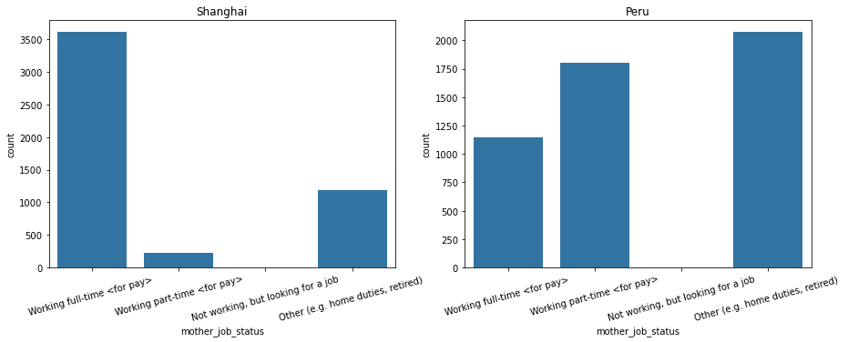

```python
#Visualization of relative frequency of job status of mothers

plt.figure(figsize=(15,5))

plt.subplot(1,2,1)
sb.countplot(data=shanghai, x='mother_job_status', color=base_color)
plt.xticks(rotation=15)
plt.title('Shanghai')

plt.subplot(1,2,2)
sb.countplot(data=peru, x='mother_job_status', color=base_color)
plt.xticks(rotation=15)
plt.title('Peru');
```

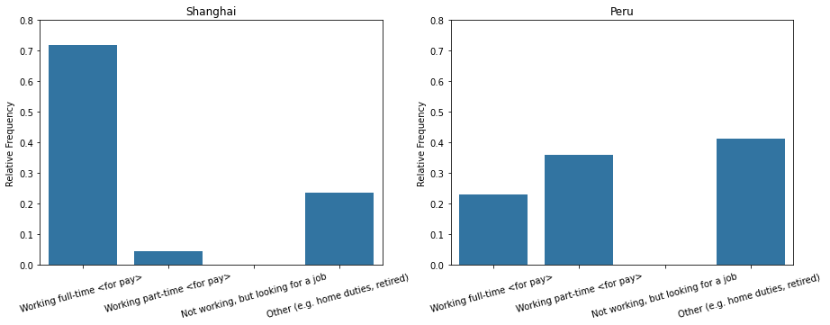

```python
#Visualization of average math results depending on mothers job status

x1 = shanghai['mother_job_status'].value_counts()
shanghai_rel = pd.DataFrame(data=x1)
shanghai_rel['mother_job_status'] = shanghai_rel['mother_job_status'].astype(float)
y1 = shanghai['mother_job_status'].value_counts().sum()
shanghai_rel['mother_job_status_rel'] = shanghai_rel['mother_job_status'] / y1

x2 = peru['mother_job_status'].value_counts()
peru_rel = pd.DataFrame(data=x2)
peru_rel['mother_job_status'] = peru_rel['mother_job_status'].astype(float)
y2 = peru['mother_job_status'].value_counts().sum()
peru_rel['mother_job_status_rel'] = peru_rel['mother_job_status'] / y2

plt.figure(figsize=(15,5))

plt.subplot(1,2,1)

x3 = shanghai_rel.index.values
y3 = shanghai_rel.mother_job_status_rel.values

g = sb.barplot(x3, y3, color=base_color)
g.set_ylim(0, 0.8)
g.set(ylabel='Relative Frequency')
plt.xticks(rotation=15)
plt.title('Shanghai')

plt.subplot(1,2,2)

x4 = peru_rel.index.values
y4 = peru_rel.mother_job_status_rel.values

g = sb.barplot(x4, y4, color=base_color)
g.set_ylim(0, 0.8)
g.set(ylabel='Relative Frequency')
plt.xticks(rotation=15)
plt.title('Peru');
```

There is a difference in both countries.

Most mothers work full-time in Shanghai.

Most mothers are not working in Peru, followed by part-time work. Only about 20% of mothers are working full-time.

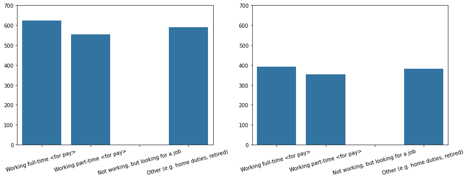

```python
#Visualization of average math results depending on mothers job status

shanghai_control_mean = shanghai.groupby(['mother_job_status']).mean()
peru_control_mean = peru.groupby(['mother_job_status']).mean()

plt.figure(figsize=(15,5))

plt.subplot(1,2,1)
x = shanghai_control_mean.index.values
y = shanghai_control_mean.math.values
g = sb.barplot(x, y, color=base_color)
g.set_ylim(0, 700)
plt.xticks(rotation=15)

plt.subplot(1,2,2)
x = peru_control_mean.index.values
y = peru_control_mean.math.values
g = sb.barplot(x, y, color=base_color)
g.set_ylim(0, 700)
plt.xticks(rotation=15);
```

In both countries the students of full-time working mothers perform best. The order of average results is the same in both countries.

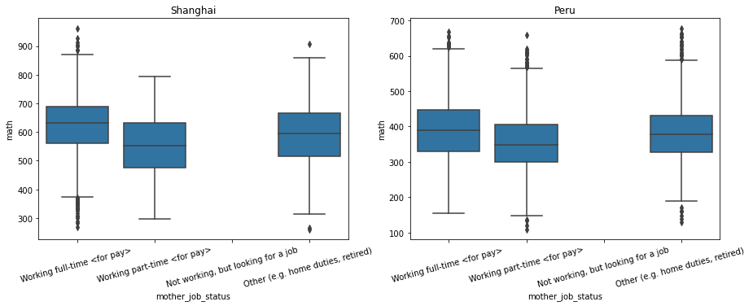

```python
#Visualization of distribution of math results depending on fathers job status
plt.figure(figsize=(15,5))

plt.subplot(1,2,1)
sb.boxplot(data=shanghai, x='mother_job_status', y='math', color=base_color)
plt.xticks(rotation=15)
plt.title('Shanghai')

plt.subplot(1,2,2)
sb.boxplot(data=peru, x='mother_job_status', y='math', color=base_color)
plt.xticks(rotation=15)
plt.title('Peru');
```

Students of full-time working mothers achieve the highest average results in both countries.

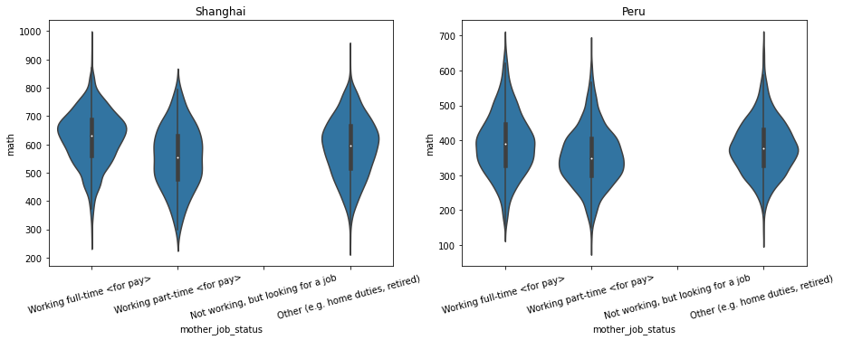

```python
#Visualization of distribution of math results depending on mothers job status

plt.figure(figsize=(15,5))

plt.subplot(1,2,1)
sb.violinplot(data=shanghai, x='mother_job_status', y='math', color=base_color)
plt.xticks(rotation=15)
plt.title('Shanghai')

plt.subplot(1,2,2)
sb.violinplot(data=peru, x='mother_job_status', y='math', color=base_color)
plt.xticks(rotation=15)
plt.title('Peru');
```

## Summary

##### What influence does belonging to OECD have on the dependent variables?

Average math results of students in OECD countries are better.

##### What influence does the gender of the student have on the dependent variables?

Male students achieve better math results on average.

##### What influence does the access to a computer have on the dependent variable?

Students that have access to a computer achieve better average math results.

##### What influence does the access to the internet have on the dependent variable?

Students that have internet access achieve better average math results.

##### What influence does the self concept of students ('I am good at math') have on the dependent variable?

The more students disagree with the statement that they are not good at math, the better their average math results are.

##### What influence does the perceived control of students have on the dependent variable?

The more students agree with the statement that more effort leads to better results, the better their average math results are.

##### What influence does the education of mother / father have on the dependent variables?

Students which parents achieved ISCED level 3A (second highest education level) achieve the best average math results.

Male students perform slightly better compared to female students independent of education of their parents.

##### What influence does the job status of mother/father have on the dependent variables?

Students which parents are working full-time achieve best average math results.

##### What influence does the country (two examples of best and worst country) have on the dependent variables?

There is significant variance in the average results in the countries.

Shanghai and Peru are the countries with the best and worst overall pisa results, e.g. in math, reading and science.

Generally, the same trends are visible in both countries, Shanghai and Peru, compared to the analysis with all countries.

- E.g. male students perform slightly better.
- E.g. if students have access to a computer the results are better.
- E.g. if students have access to internet the results are better.
- E.g. if self concept is more positive the results of students are better.
- E.g. if perceived control is higher the results of students are better.
- E.g. education and job status of parents show same trends.

However, the average results of students in Peru is significantly worse.